# Этап индивидуального проекта №3

Операционные системы

Кузьмин Егор Витальевич, НКАбд-03-23

Российский университет дружбы народов, Москва, Россия

25 марта 2024

## Цель работы

Продолжить работу с сайтом, теперь нужно добавить личную информацию, пару постов

## Задание

0. Ознакомиться с заданием и нюансами.
1. Добавить информацию о навыках (Skills).
2. Добавить информацию об опыте (Experience).
3. Добавить информацию о достижениях (Accomplishments).
4. Сделать пост по прошедшей неделе.
5. Добавить пост на тему по выбору.

## Выполнение проекта

Захожу в терминал, перехожу в директорию ~/work/blog, ввожу команду ~/bin/hugo server для запуска локального сервера

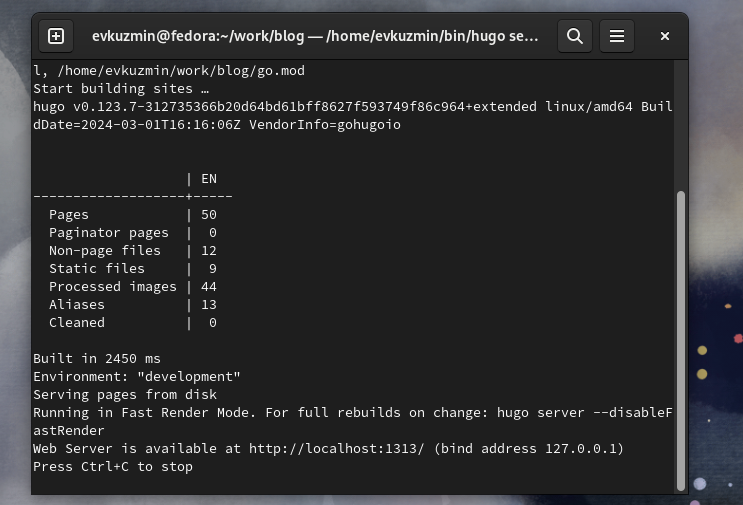

Запуск локального сервера

## Выполнение проекта

- Перехожу в директорию ~/work/blog/content/authors/admin
- Открываю файл _index.md, его я буду редактировать далее
- В разделе “Skills” прописываю свои навыки
- Иконки поставил, найдя в интернете официальную библиотеку fas

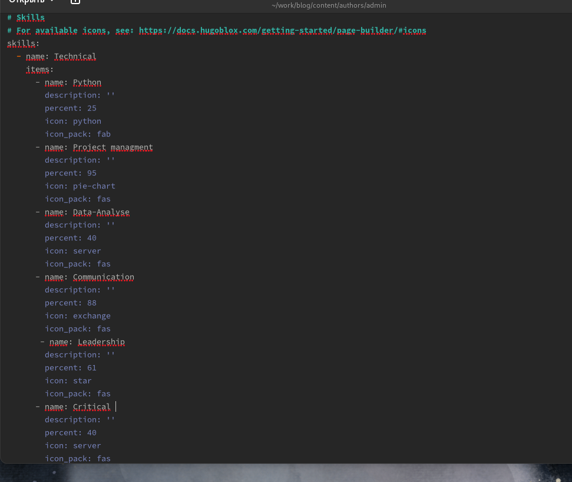

Добавление навыков

## Выполнение проекта

Изменяю раздел с моими увлечениями

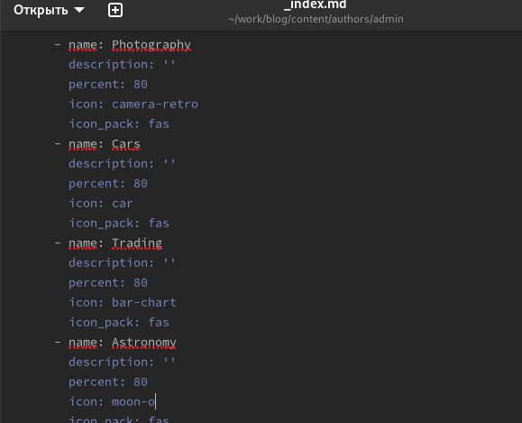

Добавление интересов

## Выполнение проекта

Проверяю, есть ли изменения на сайте

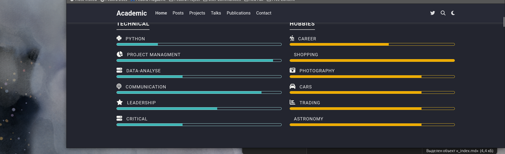

Проверка изменений

## Выполнение проекта

- название компании, в которой получил опыт работы
- даты, иконки

[figure not shown]

## Выполнение проекта

Добавил пост на тему по выбору - легкословесные языки разметки, изменив файл index в соответствующей папке

[figure not shown]

Добавление поста на тему по выбору

## Выполнение проекта

Добавил пост по прошедшим 5 дням в той же папке

[figure not shown]

Добавление поста по прошедшей неделе

## Выполнение проекта

Закрываю локальный сервер с помощью клавиш Ctrl+C и собираю сайт с изменениями, введя команду ~/bin/hugo без аргументов

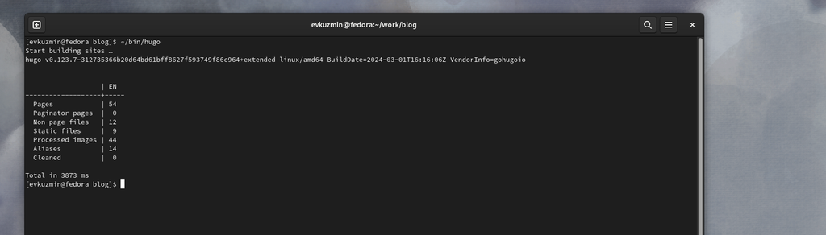

Закрытие локального сервера

## Выполнение проекта

Отправляю изменения на GitHub

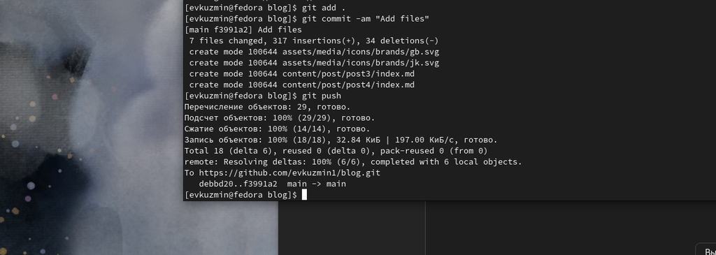

Отправка изменений на Git

## Выполнение проекта

Перехожу в директорию blog/public и отправляю изменения на GitHub, чтобы глобальный сайт тоже был обновлен

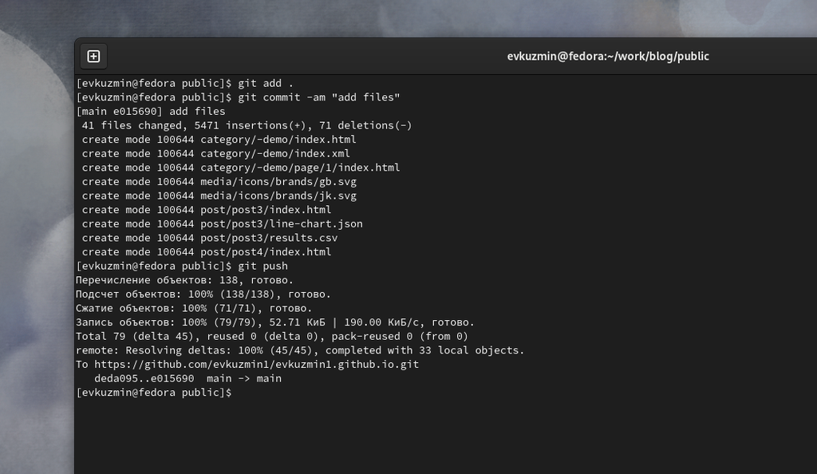

Отправка изменений на Git

## Выполнение проекта

Проверяю, что все сделано корректно

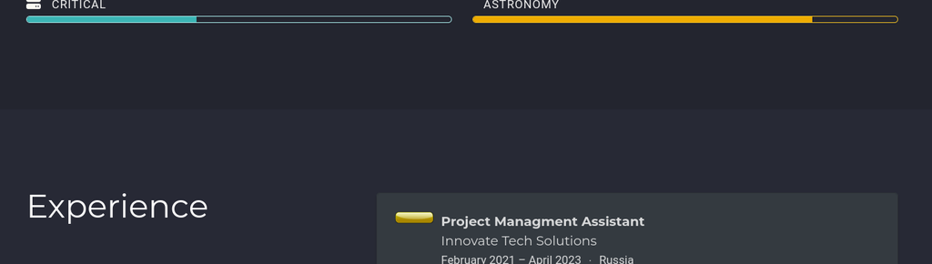

Результат выполнения работы